# ANOVA de dos factores

PSI4035 Taller 07

dacarras

# Taller 7: ANOVA de dos factores

## Cargar datos

```r
#----------------------------------------------------------
# cargar datos
#----------------------------------------------------------

#--------------------------------------
# cargar dplyr
#--------------------------------------

library(dplyr)

#--------------------------------------
# datos Vik (2014, p128)
#--------------------------------------

table_11_1 <- read.table(text = "
person  score   sex    diag
      1     3     m    none
      2     5     m    none
      3     6     m    none
      4     8     m    none
      5     9     m    none
      6    11     m    none
      7    19     m    depressed
      8    15     m    depressed
      9    16     m    depressed
     10    16     m    depressed
     11    19     m    depressed
     12    17     m    depressed
     13     3     f    none
     14     5     f    none
     15     4     f    none
     16     6     f    none
     17     8     f    none
     18    10     f    none
     19    24     f    depressed
     20    24     f    depressed
     21    22     f    depressed
     22    23     f    depressed
     23    19     f    depressed
     24    20     f    depressed
", header = TRUE, stringsAsFactors = FALSE)

#--------------------------------------
# mostrar datos
#--------------------------------------

knitr::kable(table_11_1, digits = 3)
```

| person | score | sex | diag |
| --- | --- | --- | --- |
| 1 | 3 | m | none |
| 2 | 5 | m | none |
| 3 | 6 | m | none |
| 4 | 8 | m | none |
| 5 | 9 | m | none |
| 6 | 11 | m | none |
| 7 | 19 | m | depressed |
| 8 | 15 | m | depressed |
| 9 | 16 | m | depressed |
| 10 | 16 | m | depressed |
| 11 | 19 | m | depressed |
| 12 | 17 | m | depressed |
| 13 | 3 | f | none |
| 14 | 5 | f | none |
| 15 | 4 | f | none |
| 16 | 6 | f | none |
| 17 | 8 | f | none |
| 18 | 10 | f | none |
| 19 | 24 | f | depressed |
| 20 | 24 | f | depressed |
| 21 | 22 | f | depressed |
| 22 | 23 | f | depressed |
| 23 | 19 | f | depressed |
| 24 | 20 | f | depressed |

## Descriptivos

```r
#----------------------------------------------------------
# descriptivos
#----------------------------------------------------------

#--------------------------------------
# casos por factor
#--------------------------------------

xtabs(~ sex + diag, data = table_11_1)
```

```
##    diag
## sex depressed none
##   f         6    6
##   m         6    6
```

```r
#--------------------------------------
# descriptivos por sexo
#--------------------------------------

table_11_1 %>%
group_by(sex) %>%
summarize(
    mean = mean(score, na.rm = TRUE),
    sd = sd(score, na.rm = TRUE),
    n = n()
    ) %>%
knitr::kable(., digits = 2)
```

| sex | mean | sd | n |
| --- | --- | --- | --- |
| f | 14 | 8.66 | 12 |
| m | 12 | 5.69 | 12 |

```r
#--------------------------------------
# descriptivos por diagnostico
#--------------------------------------

table_11_1 %>%
group_by(diag) %>%
summarize(
    mean = mean(score, na.rm = TRUE),
    sd = sd(score, na.rm = TRUE),
    n = n()
    ) %>%
knitr::kable(., digits = 2)
```

| diag | mean | sd | n |
| --- | --- | --- | --- |
| depressed | 19.5 | 3.18 | 12 |
| none | 6.5 | 2.68 | 12 |

```r
#--------------------------------------
# descriptivos por celda
#--------------------------------------

table_11_1 %>%
group_by(sex, diag) %>%
summarize(
    mean = mean(score, na.rm = TRUE),
    sd = sd(score, na.rm = TRUE),
    n = n()
    ) %>%
knitr::kable(., digits = 2)
```

[output not shown]

| sex | diag | mean | sd | n |
| --- | --- | --- | --- | --- |
| f | depressed | 22 | 2.10 | 6 |
| f | none | 6 | 2.61 | 6 |
| m | depressed | 17 | 1.67 | 6 |
| m | none | 7 | 2.90 | 6 |

# ANOVA enfoque tradicional

```r
#----------------------------------------------------------
# ANOVA
#----------------------------------------------------------


#--------------------------------------
# anova two factors
#--------------------------------------

anova(with(table_11_1, aov(score ~ sex*diag)))
```

```
## Analysis of Variance Table
##
## Response: score
##           Df Sum Sq Mean Sq  F value           Pr(>F)
## sex        1     24    24.0   4.2857         0.051595 .
## diag       1   1014  1014.0 181.0714 0.00000000001751 ***
## sex:diag   1     54    54.0   9.6429         0.005577 **
## Residuals 20    112     5.6
## ---
## Signif. codes:  0 '***' 0.001 '**' 0.01 '*' 0.05 '.' 0.1 ' ' 1
```

```r
#--------------------------------------
# anova two factors
#--------------------------------------

table_11_1 %>%
aov(score ~ sex*diag, data = .) %>%
anova()
```

```
## Analysis of Variance Table
##
## Response: score
##           Df Sum Sq Mean Sq  F value           Pr(>F)
## sex        1     24    24.0   4.2857         0.051595 .
## diag       1   1014  1014.0 181.0714 0.00000000001751 ***
## sex:diag   1     54    54.0   9.6429         0.005577 **
## Residuals 20    112     5.6
## ---
## Signif. codes:  0 '***' 0.001 '**' 0.01 '*' 0.05 '.' 0.1 ' ' 1
```

```r
#--------------------------------------
# anova two factors
#--------------------------------------

rstatix::anova_test(score ~ sex + diag + sex*diag, data = table_11_1)
```

```
## Coefficient covariances computed by hccm()
```

```
## ANOVA Table (type II tests)
##
##     Effect DFn DFd       F               p p<.05   ges
## 1      sex   1  20   4.286 0.0520000000000       0.176
## 2     diag   1  20 181.071 0.0000000000175     * 0.901
## 3 sex:diag   1  20   9.643 0.0060000000000     * 0.325
```

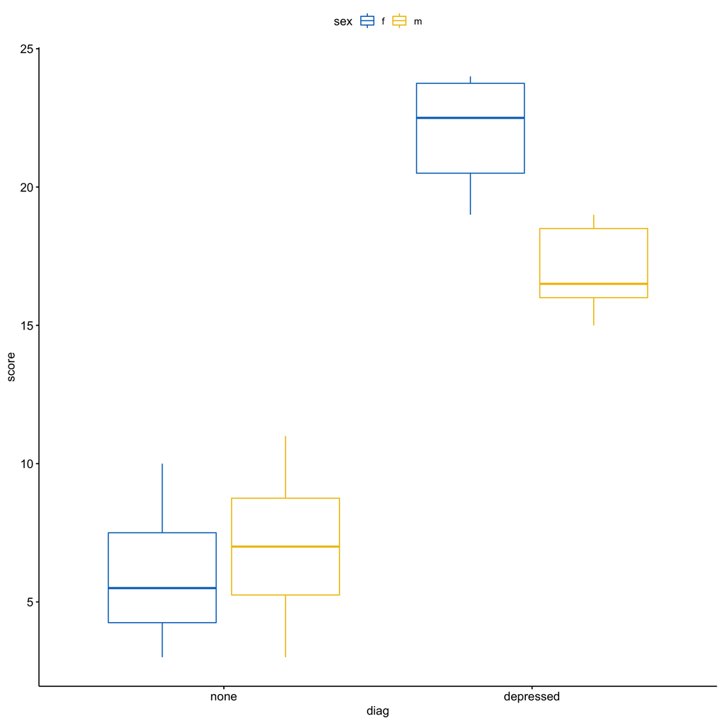

```r
#--------------------------------------
# boxplot (score by diag)
#--------------------------------------

ggpubr::ggboxplot(
  table_11_1, x = "diag", y = "score",
  color = "sex", palette = "jco"
  )
```

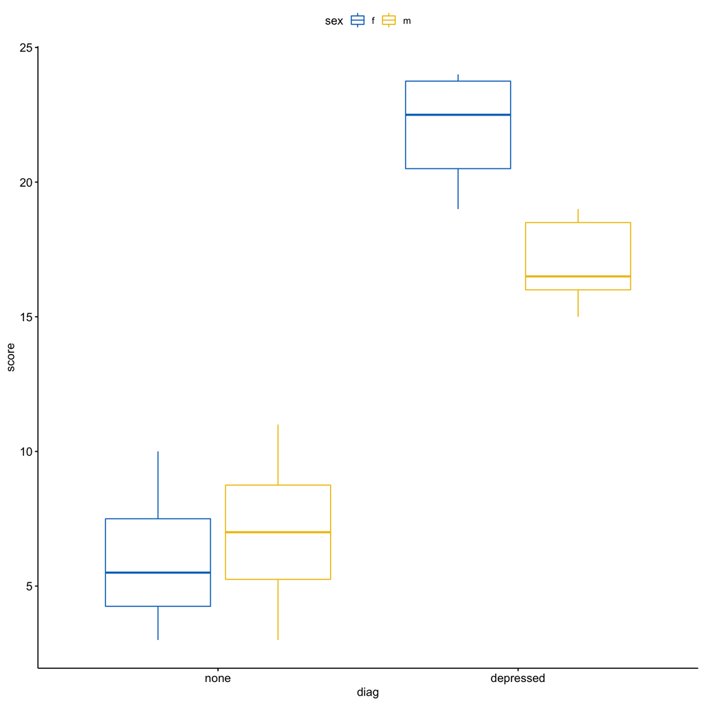

```r
#--------------------------------------
# boxplot (score by sex)
#--------------------------------------

ggpubr::ggboxplot(
  table_11_1, x = "diag", y = "score",
  color = "sex", palette = "jco"
  )
```

# ANOVA via regresión

```r
#----------------------------------------------------------
# ANOVA via regresión
#----------------------------------------------------------

#--------------------------------------
# preparar datos
#--------------------------------------

data_model <- table_11_1 %>%
              mutate(sex_dev = case_when(
                sex == 'f' ~ -1,
                sex == 'm' ~  1
                )) %>%
              mutate(diag_dev = case_when(
                diag == 'depressed' ~  1,
                diag == 'none' ~ -1
                )) %>%
              mutate(int = sex_dev*diag_dev) %>%
              dplyr::glimpse()
```

```
## Rows: 24
## Columns: 7
## $ person   <int> 1, 2, 3, 4, 5, 6, 7, 8, 9, 10, 11, 12, 13, 14, 15, 16, 17, 18…
## $ score    <int> 3, 5, 6, 8, 9, 11, 19, 15, 16, 16, 19, 17, 3, 5, 4, 6, 8, 10,…
## $ sex      <chr> "m", "m", "m", "m", "m", "m", "m", "m", "m", "m", "m", "m", "…
## $ diag     <chr> "none", "none", "none", "none", "none", "none", "depressed", …
## $ sex_dev  <dbl> 1, 1, 1, 1, 1, 1, 1, 1, 1, 1, 1, 1, -1, -1, -1, -1, -1, -1, -…
## $ diag_dev <dbl> -1, -1, -1, -1, -1, -1, 1, 1, 1, 1, 1, 1, -1, -1, -1, -1, -1,…
## $ int      <dbl> -1, -1, -1, -1, -1, -1, 1, 1, 1, 1, 1, 1, 1, 1, 1, 1, 1, 1, -…
```

```r
#--------------------------------------
# mostrar datos
#--------------------------------------

knitr::kable(data_model)
```

| person | score | sex | diag | sex_dev | diag_dev | int |
| --- | --- | --- | --- | --- | --- | --- |
| 1 | 3 | m | none | 1 | -1 | -1 |
| 2 | 5 | m | none | 1 | -1 | -1 |
| 3 | 6 | m | none | 1 | -1 | -1 |
| 4 | 8 | m | none | 1 | -1 | -1 |
| 5 | 9 | m | none | 1 | -1 | -1 |
| 6 | 11 | m | none | 1 | -1 | -1 |
| 7 | 19 | m | depressed | 1 | 1 | 1 |
| 8 | 15 | m | depressed | 1 | 1 | 1 |
| 9 | 16 | m | depressed | 1 | 1 | 1 |
| 10 | 16 | m | depressed | 1 | 1 | 1 |
| 11 | 19 | m | depressed | 1 | 1 | 1 |
| 12 | 17 | m | depressed | 1 | 1 | 1 |
| 13 | 3 | f | none | -1 | -1 | 1 |
| 14 | 5 | f | none | -1 | -1 | 1 |
| 15 | 4 | f | none | -1 | -1 | 1 |
| 16 | 6 | f | none | -1 | -1 | 1 |
| 17 | 8 | f | none | -1 | -1 | 1 |
| 18 | 10 | f | none | -1 | -1 | 1 |
| 19 | 24 | f | depressed | -1 | 1 | -1 |
| 20 | 24 | f | depressed | -1 | 1 | -1 |
| 21 | 22 | f | depressed | -1 | 1 | -1 |
| 22 | 23 | f | depressed | -1 | 1 | -1 |
| 23 | 19 | f | depressed | -1 | 1 | -1 |
| 24 | 20 | f | depressed | -1 | 1 | -1 |

```r
#--------------------------------------
# formulas
#--------------------------------------

f01 <- as.formula(score ~ + 1 + sex_dev + diag_dev + int)
f02 <- as.formula(score ~ + 1 + diag_dev + int)       # sin sexo
f03 <- as.formula(score ~ + 1 + sex_dev + int)        # sin diagnostico
f04 <- as.formula(score ~ + 1 + sex_dev + diag_dev)   # sin interaccion

#--------------------------------------
# ajustar modelos
#--------------------------------------

m01 <- lm(f01, data = data_model)
m02 <- lm(f02, data = data_model)
m03 <- lm(f03, data = data_model)
m04 <- lm(f04, data = data_model)


#--------------------------------------
# tabla de modelos
#--------------------------------------

texreg::screenreg(
    list(m01, m02, m03, m04),
    star.symbol = "*",
    center = TRUE,
    doctype = FALSE,
    dcolumn = TRUE,
    booktabs = TRUE,
    single.row = FALSE
    )
```

```
##
## =======================================================
##              Model 1    Model 2    Model 3    Model 4
## -------------------------------------------------------
## (Intercept)  13.00 ***  13.00 ***  13.00 ***  13.00 ***
##              (0.48)     (0.52)     (1.49)     (0.57)
## sex_dev      -1.00                 -1.00      -1.00
##              (0.48)                (1.49)     (0.57)
## diag_dev      6.50 ***   6.50 ***              6.50 ***
##              (0.48)     (0.52)                (0.57)
## int          -1.50 **   -1.50 **   -1.50
##              (0.48)     (0.52)     (1.49)
## -------------------------------------------------------
## R^2           0.91       0.89       0.06       0.86
## Adj. R^2      0.89       0.88      -0.02       0.85
## Num. obs.    24         24         24         24
## =======================================================
## *** p < 0.001; ** p < 0.01; * p < 0.05
```

```r
#--------------------------------------
# test por termino
#--------------------------------------

survey::regTermTest(m01,c('sex_dev'))
```

```
## Wald test for sex_dev
##  in lm(formula = f01, data = data_model)
## F =  4.285714  on  1  and  20  df: p= 0.051595
```

```r
survey::regTermTest(m01,c('diag_dev'))
```

```
## Wald test for diag_dev
##  in lm(formula = f01, data = data_model)
## F =  181.0714  on  1  and  20  df: p= 0.000000000017514
```

```r
survey::regTermTest(m01,c('int'))
```

```
## Wald test for int
##  in lm(formula = f01, data = data_model)
## F =  9.642857  on  1  and  20  df: p= 0.0055775
```

```r
#--------------------------------------
# output tradicional
#--------------------------------------

summary(m01)
```

```
##
## Call:
## lm(formula = f01, data = data_model)
##
## Residuals:
##    Min     1Q Median     3Q    Max
##     -4     -2      0      2      4
##
## Coefficients:
##             Estimate Std. Error t value             Pr(>|t|)
## (Intercept)   13.000      0.483  26.913 < 0.0000000000000002 ***
## sex_dev       -1.000      0.483  -2.070              0.05160 .
## diag_dev       6.500      0.483  13.456      0.0000000000175 ***
## int           -1.500      0.483  -3.105              0.00558 **
## ---
## Signif. codes:  0 '***' 0.001 '**' 0.01 '*' 0.05 '.' 0.1 ' ' 1
##
## Residual standard error: 2.366 on 20 degrees of freedom
## Multiple R-squared:  0.907,  Adjusted R-squared:  0.893
## F-statistic:    65 on 3 and 20 DF,  p-value: 0.0000000001718
```

```r
#--------------------------------------
# output como anova
#--------------------------------------

anova(m01)
```

```
## Analysis of Variance Table
##
## Response: score
##           Df Sum Sq Mean Sq  F value           Pr(>F)
## sex_dev    1     24    24.0   4.2857         0.051595 .
## diag_dev   1   1014  1014.0 181.0714 0.00000000001751 ***
## int        1     54    54.0   9.6429         0.005577 **
## Residuals 20    112     5.6
## ---
## Signif. codes:  0 '***' 0.001 '**' 0.01 '*' 0.05 '.' 0.1 ' ' 1
```

```r
#--------------------------------------
# expected means
#--------------------------------------

emmeans::emmeans(m01,
    specs = pairwise ~ sex_dev:diag_dev,
    type = "response",
    adjust = "bonferroni")
```

```
## $emmeans
##  sex_dev diag_dev emmean    SE df lower.CL upper.CL
##       -1       -1    7.5 0.837 20     5.75     9.25
##        1       -1    5.5 0.837 20     3.75     7.25
##       -1        1   20.5 0.837 20    18.75    22.25
##        1        1   18.5 0.837 20    16.75    20.25
##
## Results are averaged over the levels of: int
## Confidence level used: 0.95
##
## $contrasts
##  contrast         estimate    SE df t.ratio p.value
##  (-1 -1) - (1 -1)        2 0.966 20   2.070  0.3096
##  (-1 -1) - (-1 1)      -13 0.966 20 -13.456  <.0001
##  (-1 -1) - 1 1         -11 1.366 20  -8.051  <.0001
##  (1 -1) - (-1 1)       -15 1.366 20 -10.979  <.0001
##  (1 -1) - 1 1          -13 0.966 20 -13.456  <.0001
##  (-1 1) - 1 1            2 0.966 20   2.070  0.3096
##
## Results are averaged over the levels of: int
## P value adjustment: bonferroni method for 6 tests
```

## Comparar modelos

```r
#----------------------------------------------------------
# comparar modelos
#----------------------------------------------------------

#--------------------------------------
# anova: model trimming (sexo)
#--------------------------------------

anova(m01, m02)
```

```
## Analysis of Variance Table
##
## Model 1: score ~ +1 + sex_dev + diag_dev + int
## Model 2: score ~ +1 + diag_dev + int
##   Res.Df RSS Df Sum of Sq      F Pr(>F)
## 1     20 112
## 2     21 136 -1       -24 4.2857 0.0516 .
## ---
## Signif. codes:  0 '***' 0.001 '**' 0.01 '*' 0.05 '.' 0.1 ' ' 1
```

```r
#--------------------------------------
# anova: model trimming (diag)
#--------------------------------------

anova(m01, m03)
```

```
## Analysis of Variance Table
##
## Model 1: score ~ +1 + sex_dev + diag_dev + int
## Model 2: score ~ +1 + sex_dev + int
##   Res.Df  RSS Df Sum of Sq      F           Pr(>F)
## 1     20  112
## 2     21 1126 -1     -1014 181.07 0.00000000001751 ***
## ---
## Signif. codes:  0 '***' 0.001 '**' 0.01 '*' 0.05 '.' 0.1 ' ' 1
```

```r
#--------------------------------------
# anova: model trimming (int)
#--------------------------------------

anova(m01, m04)
```

```
## Analysis of Variance Table
##
## Model 1: score ~ +1 + sex_dev + diag_dev + int
## Model 2: score ~ +1 + sex_dev + diag_dev
##   Res.Df RSS Df Sum of Sq      F   Pr(>F)
## 1     20 112
## 2     21 166 -1       -54 9.6429 0.005577 **
## ---
## Signif. codes:  0 '***' 0.001 '**' 0.01 '*' 0.05 '.' 0.1 ' ' 1
```

# Ejemplo 1: interaccion entre variables dicotómicas

Para ilustrar una interacción, vamos a emplear datos de Abrevaya (2006). Estos son una serie de registros del peso al nacer de los hijos de diferentes madres. La motivación del estudio, es evaluar el efecto que posee el fumar en el peso de los nacidos. Este ejemplo se encuentra discutido con mayor profundidad en Rabe-Hesketh & Skrondal (2012), y consiste en un 10% de los datos originales (n = 3978 madres).

En el caso de la regresión múltiple, nos sigue interesando los valores esperados de y_i, condicionales a los valores de x_i y otras covariables.

Primero vamos a evaluar la interacción de dos variables dicotómicas.

## Abrir datos

```r
#----------------------------------------------------------
# abrir datos
#----------------------------------------------------------

# -----------------------------------------------
# abrir datos desde github
# -----------------------------------------------

data_smoke <- haven::read_dta(
url('https://github.com/dacarras/psi4035_examples/raw/master/data/smoking.dta')
)

# Nota: el formato original de los datos, esta en STATA.
#       empleamos haven::read_dta() para abrir datos en este formato.

# -----------------------------------------------
# inspeccionar datos
# -----------------------------------------------

data_smoke %>%
labelled::look_for() %>%
labelled::lookfor_to_long_format() %>%
tibble::as_tibble() %>%
knitr::kable()
```

[output not shown]

[output cut: 97 more lines]

## Preparar datos

Seleccionamos los datos del primer hijo, de modo que tengamos datos independientes. En caso contrario, tendríamos datos de más de un nacido de una misma madres, y estaríamos violando el supuesto de independencia de las observaciones.

Vamos a emplear solo tres medidas: el peso al nacer, si la madre fuma (0 = no fuma; 1 = si fuma), y si ha faltado a los controles pre natales (1 = sin visita, 0 = con visitas).

El peso de los recién nacidos esta en gramos, así que lo convertiremos a kilos, de modo que sea más fácil de interpretar (i.e. leer los estimados en Kg.).

Luego ajustamos los modelos de regresión en pasos. Primero solo la covariable de interés (smoke). Luego, el posible moderador (novisit), y finalmente un modelo con ambos predictores y su interacción.

Cambiamos las variables dicotomicas, a variables de contratse:

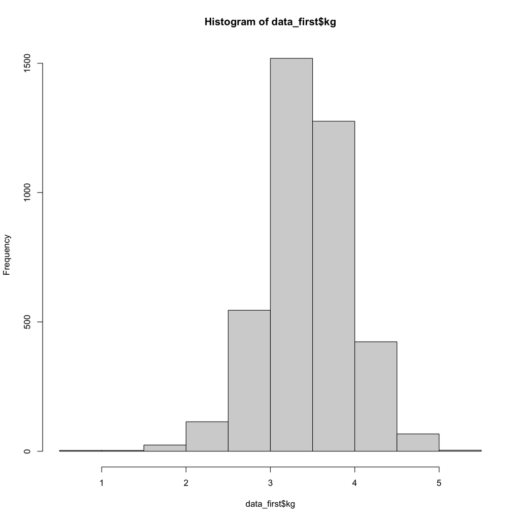

```r
#----------------------------------------------------------
# preparar datos
#----------------------------------------------------------

# -----------------------------------------------
# variables de interes
# -----------------------------------------------

# momid   = indicador único de la madre
# idx     = orden de los nacidos para cada madre
# birwt   = peso al nacer en gramos
# smoke   = madre es fumadora (sí = 1; no = 0)
# novisit = no asiste al control prenatal (no = 1; sí = 0)


# -----------------------------------------------
# funcion para remover meta data
# -----------------------------------------------

remove_labels <- function (x) {
    data <- dplyr::mutate(x, across(everything(), as.vector))
    return(data)
}

# -----------------------------------------------
# preparar datos
# -----------------------------------------------

data_first <- data_smoke %>%
              # seleccionamos datos solo del primer hijo
              dplyr::filter(idx == 1) %>%
              # transformamos el peso a kilogramos
              mutate(kg = birwt/1000) %>%
              # seleccionamos solo los datos que vamos a emplear
              dplyr::select(momid, idx, kg, smoke, novisit) %>%
              mutate(smoke_d = case_when(
                smoke == 1 ~  1, # si fuma
                smoke == 0 ~ -1  # no fuma
                )) %>%
              mutate(visit_d = case_when(
                novisit == 1 ~ -1, # no visita
                novisit == 0 ~  1  # visita
                )) %>%
              mutate(int = smoke_d*visit_d) %>%
              remove_labels() %>%
              as.data.frame()


# -----------------------------------------------
# histograma
# -----------------------------------------------

hist(data_first$kg)
```

```r
# -----------------------------------------------
# mostrar datos de 20 casos
# -----------------------------------------------

data_first %>%
dplyr::sample_n(20) %>%
tibble::as_tibble() %>%
knitr::kable()
```

| momid | idx | kg | smoke | novisit | smoke_d | visit_d | int |
| --- | --- | --- | --- | --- | --- | --- | --- |
| 37535 | 1 | 3.345 | 0 | 0 | -1 | 1 | -1 |
| 8528 | 1 | 3.494 | 0 | 0 | -1 | 1 | -1 |
| 3155 | 1 | 3.629 | 0 | 0 | -1 | 1 | -1 |
| 52273 | 1 | 3.629 | 0 | 0 | -1 | 1 | -1 |
| 30777 | 1 | 3.771 | 0 | 0 | -1 | 1 | -1 |
| 18316 | 1 | 4.026 | 0 | 0 | -1 | 1 | -1 |
| 63155 | 1 | 4.082 | 0 | 0 | -1 | 1 | -1 |
| 20188 | 1 | 1.077 | 1 | 0 | 1 | 1 | 1 |
| 20369 | 1 | 3.714 | 0 | 0 | -1 | 1 | -1 |
| 16704 | 1 | 3.515 | 0 | 0 | -1 | 1 | -1 |
| 65784 | 1 | 2.825 | 0 | 0 | -1 | 1 | -1 |
| 10754 | 1 | 3.856 | 1 | 0 | 1 | 1 | 1 |
| 45665 | 1 | 2.258 | 0 | 0 | -1 | 1 | -1 |
| 26753 | 1 | 3.544 | 0 | 0 | -1 | 1 | -1 |
| 82925 | 1 | 4.394 | 0 | 0 | -1 | 1 | -1 |
| 47346 | 1 | 3.620 | 0 | 0 | -1 | 1 | -1 |
| 16348 | 1 | 3.459 | 0 | 0 | -1 | 1 | -1 |
| 17939 | 1 | 2.155 | 0 | 0 | -1 | 1 | -1 |
| 15503 | 1 | 3.402 | 0 | 0 | -1 | 1 | -1 |
| 5690 | 1 | 4.564 | 0 | 0 | -1 | 1 | -1 |

## Ajustar models

```r
#----------------------------------------------------------
# model comparison
#----------------------------------------------------------

# -----------------------------------------------
# equation
# -----------------------------------------------

f00 <- as.formula('kg ~ 1')
f01 <- as.formula('kg ~ 1 + smoke_d')
f02 <- as.formula('kg ~ 1 + visit_d')
f03 <- as.formula('kg ~ 1 + smoke_d + visit_d')
f04 <- as.formula('kg ~ 1 + smoke_d*visit_d')

# -----------------------------------------------
# regressions
# -----------------------------------------------

s00 <- lm(f00, data = data_first)
s01 <- lm(f01, data = data_first)
s02 <- lm(f02, data = data_first)
s03 <- lm(f03, data = data_first)
s04 <- lm(f04, data = data_first)

#--------------------------------------
# compare models
#--------------------------------------

texreg::screenreg(
    list(s00, s01, s02, s03, s04),
    star.symbol = "*",
    center = TRUE,
    doctype = FALSE,
    dcolumn = TRUE,
    booktabs = TRUE,
    single.row = FALSE
    )
```

```
##
## ================================================================================
##                  Model 1      Model 2      Model 3      Model 4      Model 5
## --------------------------------------------------------------------------------
## (Intercept)         3.44 ***     3.33 ***     3.32 ***     3.26 ***     3.25 ***
##                    (0.01)       (0.01)       (0.05)       (0.05)       (0.05)
## smoke_d                         -0.14 ***                 -0.14 ***    -0.26 ***
##                                 (0.01)                    (0.01)       (0.05)
## visit_d                                       0.12 *       0.07         0.09 *
##                                              (0.05)       (0.05)       (0.05)
## smoke_d:visit_d                                                         0.12 **
##                                                                        (0.05)
## --------------------------------------------------------------------------------
## R^2                 0.00         0.04         0.00         0.04         0.04
## Adj. R^2            0.00         0.04         0.00         0.04         0.04
## Num. obs.        3978         3978         3978         3978         3978
## ================================================================================
## *** p < 0.001; ** p < 0.01; * p < 0.05
```

Nuestra variable dependiente es el peso del primer nacido de cada mujer que participa en el estudio, en kilogramos.

En promedio, los recién nacidos presentan 3.44 kg al nacer (ver Model 1).

## Interacciones

```r
#----------------------------------------------------------
# variantes del codigo
#----------------------------------------------------------

# -----------------------------------------------
# codigo 1: empleando a ":"
# -----------------------------------------------


interaction_model <- lm(kg ~ smoke_d + visit_d + visit_d:smoke_d,
    data = data_first)

summary(interaction_model)
```

```
##
## Call:
## lm(formula = kg ~ smoke_d + visit_d + visit_d:smoke_d, data = data_first)
##
## Residuals:
##      Min       1Q   Median       3Q      Max
## -2.52762 -0.30262  0.00938  0.32138  1.79213
##
## Coefficients:
##                 Estimate Std. Error t value             Pr(>|t|)
## (Intercept)      3.24694    0.04605  70.507 < 0.0000000000000002 ***
## smoke_d         -0.25904    0.04605  -5.625         0.0000000198 ***
## visit_d          0.09080    0.04605   1.972               0.0487 *
## smoke_d:visit_d  0.11917    0.04605   2.588               0.0097 **
## ---
## Signif. codes:  0 '***' 0.001 '**' 0.01 '*' 0.05 '.' 0.1 ' ' 1
##
## Residual standard error: 0.4961 on 3974 degrees of freedom
## Multiple R-squared:  0.04188,    Adjusted R-squared:  0.04116
## F-statistic:  57.9 on 3 and 3974 DF,  p-value: < 0.00000000000000022
```

```r
# -----------------------------------------------
# codigo 2: empleando a "*"
# -----------------------------------------------

interaction_model <- lm(kg ~ smoke_d + visit_d + visit_d*smoke_d,
    data = data_first)

summary(interaction_model)
```

```
##
## Call:
## lm(formula = kg ~ smoke_d + visit_d + visit_d * smoke_d, data = data_first)
##
## Residuals:
##      Min       1Q   Median       3Q      Max
## -2.52762 -0.30262  0.00938  0.32138  1.79213
##
## Coefficients:
##                 Estimate Std. Error t value             Pr(>|t|)
## (Intercept)      3.24694    0.04605  70.507 < 0.0000000000000002 ***
## smoke_d         -0.25904    0.04605  -5.625         0.0000000198 ***
## visit_d          0.09080    0.04605   1.972               0.0487 *
## smoke_d:visit_d  0.11917    0.04605   2.588               0.0097 **
## ---
## Signif. codes:  0 '***' 0.001 '**' 0.01 '*' 0.05 '.' 0.1 ' ' 1
##
## Residual standard error: 0.4961 on 3974 degrees of freedom
## Multiple R-squared:  0.04188,    Adjusted R-squared:  0.04116
## F-statistic:  57.9 on 3 and 3974 DF,  p-value: < 0.00000000000000022
```

```r
# -----------------------------------------------
# codigo 3: empleando el producto de ambas variables
# -----------------------------------------------

interaction_model <- lm(kg ~ smoke_d + visit_d + int,
    data = data_first)

summary(interaction_model)
```

```
##
## Call:
## lm(formula = kg ~ smoke_d + visit_d + int, data = data_first)
##
## Residuals:
##      Min       1Q   Median       3Q      Max
## -2.52762 -0.30262  0.00938  0.32138  1.79213
##
## Coefficients:
##             Estimate Std. Error t value             Pr(>|t|)
## (Intercept)  3.24694    0.04605  70.507 < 0.0000000000000002 ***
## smoke_d     -0.25904    0.04605  -5.625         0.0000000198 ***
## visit_d      0.09080    0.04605   1.972               0.0487 *
## int          0.11917    0.04605   2.588               0.0097 **
## ---
## Signif. codes:  0 '***' 0.001 '**' 0.01 '*' 0.05 '.' 0.1 ' ' 1
##
## Residual standard error: 0.4961 on 3974 degrees of freedom
## Multiple R-squared:  0.04188,    Adjusted R-squared:  0.04116
## F-statistic:  57.9 on 3 and 3974 DF,  p-value: < 0.00000000000000022
```

## Visualización

```r
#----------------------------------------------------------
# visualización
#----------------------------------------------------------

# -----------------------------------------------
# fit model
# -----------------------------------------------

interaction_model <- lm(kg ~ smoke_d + visit_d + visit_d*smoke_d,
    data = data_first)

# -----------------------------------------------
# summary
# -----------------------------------------------

summary(interaction_model)
```

```
##
## Call:
## lm(formula = kg ~ smoke_d + visit_d + visit_d * smoke_d, data = data_first)
##
## Residuals:
##      Min       1Q   Median       3Q      Max
## -2.52762 -0.30262  0.00938  0.32138  1.79213
##
## Coefficients:
##                 Estimate Std. Error t value             Pr(>|t|)
## (Intercept)      3.24694    0.04605  70.507 < 0.0000000000000002 ***
## smoke_d         -0.25904    0.04605  -5.625         0.0000000198 ***
## visit_d          0.09080    0.04605   1.972               0.0487 *
## smoke_d:visit_d  0.11917    0.04605   2.588               0.0097 **
## ---
## Signif. codes:  0 '***' 0.001 '**' 0.01 '*' 0.05 '.' 0.1 ' ' 1
##
## Residual standard error: 0.4961 on 3974 degrees of freedom
## Multiple R-squared:  0.04188,    Adjusted R-squared:  0.04116
## F-statistic:  57.9 on 3 and 3974 DF,  p-value: < 0.00000000000000022
```

```r
# -----------------------------------------------
# simple slope
# -----------------------------------------------

interactions::probe_interaction(
    interaction_model,
    pred = smoke_d,
    modx = visit_d
    )
```

```
## JOHNSON-NEYMAN INTERVAL
##
## When visit_d is OUTSIDE the interval [1.64, 5.96], the slope of smoke_d is
## p < .05.
##
## Note: The range of observed values of visit_d is [-1.00, 1.00]
##
## SIMPLE SLOPES ANALYSIS
##
## Slope of smoke_d when visit_d = -1.00 (-1):
##
##    Est.   S.E.   t val.      p
## ------- ------ -------- ------
##   -0.38   0.09    -4.14   0.00
##
## Slope of smoke_d when visit_d =  1.00 (1):
##
##    Est.   S.E.   t val.      p
## ------- ------ -------- ------
##   -0.14   0.01   -12.25   0.00
```

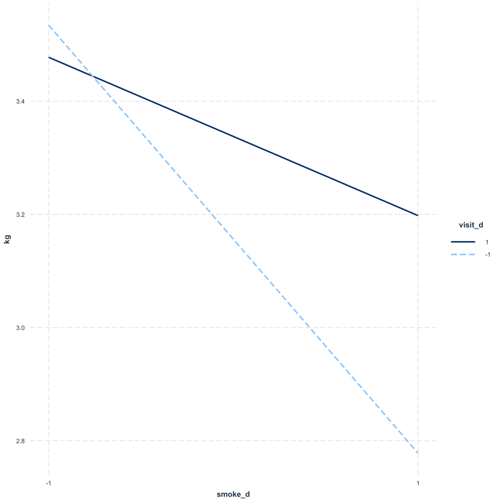

```r
# -----------------------------------------------
# simple slope
# -----------------------------------------------

interactions::probe_interaction(
    interaction_model,
    pred = visit_d,
    modx = smoke_d
    )
```

```
## JOHNSON-NEYMAN INTERVAL
##
## When smoke_d is OUTSIDE the interval [-3.19, -0.00], the slope of visit_d
## is p < .05.
##
## Note: The range of observed values of smoke_d is [-1.00, 1.00]
##
## SIMPLE SLOPES ANALYSIS
##
## Slope of visit_d when smoke_d = -1.00 (-1):
##
##    Est.   S.E.   t val.      p
## ------- ------ -------- ------
##   -0.03   0.06    -0.47   0.64
##
## Slope of visit_d when smoke_d =  1.00 (1):
##
##   Est.   S.E.   t val.      p
## ------ ------ -------- ------
##   0.21   0.07     3.02   0.00
```

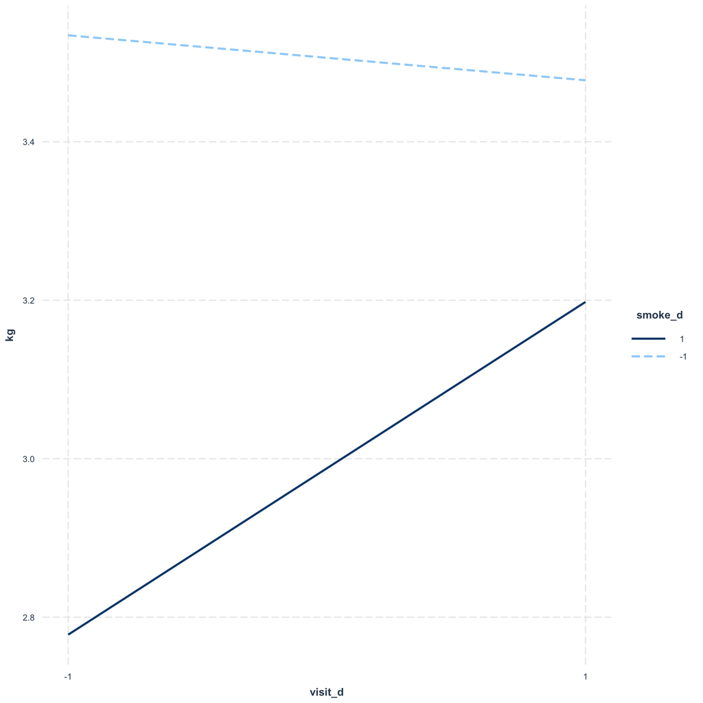

```
## JOHNSON-NEYMAN INTERVAL
##
## When visit_d is OUTSIDE the interval [1.64, 5.96], the slope of smoke_d is
## p < .05.
##
## Note: The range of observed values of visit_d is [-1.00, 1.00]
```

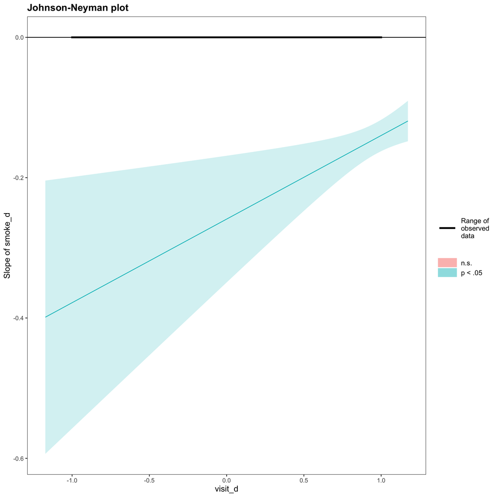

```r
# -----------------------------------------------
# johnson neyman plot
# -----------------------------------------------

interactions::johnson_neyman(
    interaction_model,
    pred = smoke_d,
    modx = visit_d
    )
```